# R Notebook

Generates figures of EK60 Data

Load in libraries

```r
library(tidyverse)
library(lubridate)
library(oce)
```

```r
PhoticBase <- 160
OMZBase <- 900
DVMBase <- 600
OMZTop <- 90
```

## EK60

Read in the data, I processed these data elsewhere, so as to avoid overloading this directory with intermediate files. 03 October 2021 – Specify that times are in UTC (not local time relative to the person using the code)

```r
dataBinned <- read_csv("data/backscatter_table_go7.csv", locale = locale(encoding = "latin1", tz="UTC"))
```

Convet to local time zone

```r
dataBinned_01 <- dataBinned %>%
  mutate(time_bin_corrected = time_bin - 60^2) %>% # the data appear to be "off" by an hour from my lab book observations, I don't know why. Correcting that  ##
  mutate(timeMex = with_tz(time_bin_corrected, tzone = "Mexico/General"))
```

Some upfront calculations

```r
startDay <- dataBinned_01$timeMex %>% na.omit %>% min %>% floor_date(unit = "days")
endDay <- dataBinned_01$timeMex %>% na.omit %>% max %>% ceiling_date(unit = "days")
timeBreaks <- seq(from = startDay, to = endDay, by = "12 hours")
timeLabels <- format(timeBreaks)
```

```r
library(suncalc)
SunTime <- getSunlightPosition(date = unique(dataBinned_01$timeMex), lat = 16.6, lon = -106.9, keep = "altitude") %>%
  filter(!is.na(date)) %>%
  rename(timeMex = date) %>%
  arrange(timeMex)
```

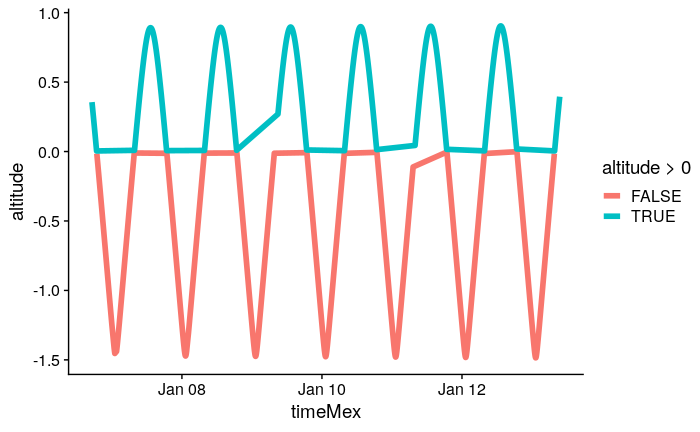

```r
SunTime %>% ggplot(aes(x = timeMex, col = altitude > 0)) + geom_line(aes(y = altitude), size = 2)
```

## Strange reslts, trying oce::SunAngle

```r
SunTime2 <- sunAngle(unique(dataBinned_01$timeMex), lat = 16.6, lon = -106.9)
SunTime2 <- bind_cols(SunTime2) %>% na.omit() %>%
  mutate(isDay = if_else(altitude >=0, "Day", "Night"))
```

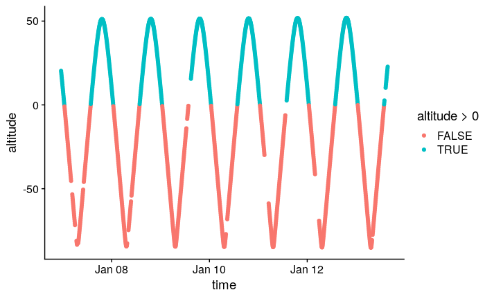

```r
ggplot(SunTime2, aes(x = time, y = altitude, color = altitude > 0)) + geom_point()
```

Adding cast times

```r
bes<- read_csv("dataOut/binned_EachSize.csv")
castTimes <- bes %>% filter(project == "ETNP") %>% group_by(time) %>% summarise(depth = max(depth)) %>% mutate(depth = if_else(depth > 1000, 1000, depth))
castTimes
```

| time | depth |
| --- | --- |
| 2017-01-08 21:08:00 | 1000 |
| 2017-01-10 02:26:00 | 325 |
| 2017-01-10 07:55:00 | 525 |
| 2017-01-10 17:15:00 | 525 |
| 2017-01-11 03:00:00 | 525 |
| 2017-01-11 08:02:00 | 525 |
| 2017-01-11 23:06:00 | 525 |
| 2017-01-12 13:11:00 | 525 |
| 2017-01-13 06:13:00 | 1000 |

# 06 October 2021

The EK60 data appear to be off by one hour, they should be shifted one hour earlier, or I should find why they are shifted back by an hour.

Plot the 18kHz data (largish animals)

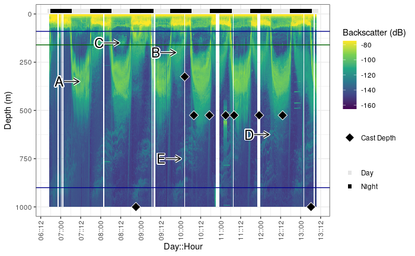

```r
# Position of letters
plotLetters <- tribble(
  ~letter, ~depth_bin, ~timeMex,
  "A", 350, as.POSIXct("2017-01-07 12:00:00"),
  "B", 200, as.POSIXct("2017-01-09 22:00:00"),
  "C", 150, as.POSIXct("2017-01-08 12:00:00"),
  "D", 625, as.POSIXct("2017-01-12 06:00:00"),
  "E", 750, as.POSIXct("2017-01-10 01:00:00")

)

library(shadowtext)
plot18k <- dataBinned_01 %>% filter(frequency == 18000) %>% ggplot(aes(x = timeMex, y = depth_bin, fill = value)) + geom_tile() + scale_y_reverse() + scale_fill_viridis_c(limits = c(-165, -75), oob = scales::squish) +
  scale_x_datetime(breaks = timeBreaks, date_labels = "%d::%H") + labs(x = "Day::Hour", y = "Depth (m)", fill = "Backscatter (dB)") + theme_bw() + theme(axis.text.x = element_text(angle = 90, vjust = 0.5)) + geom_hline(yintercept = PhoticBase, color = "darkgreen") +
  geom_hline(yintercept = OMZBase, color = "darkblue") +
    geom_hline(yintercept = OMZTop, color = "darkblue") +
  #geom_hline(yintercept = 600, color = "darkgoldenrod", lty = "dashed") +
  geom_shadowtext(data = plotLetters, aes(x = timeMex - 12 * 60^2, y = depth_bin, label = letter),  inherit.aes = FALSE, size = 6, bg.color = "white", color = "black") +
  geom_segment(data = plotLetters, inherit.aes = FALSE, aes(x = timeMex - 9 * 60^2, xend = timeMex, y = depth_bin, yend = depth_bin), arrow = arrow(length = unit(0.03, "npc")), color = "white", size = 1.5) +
  geom_segment(data = plotLetters, inherit.aes = FALSE, aes(x = timeMex - 9 * 60^2, xend = timeMex, y = depth_bin, yend = depth_bin), arrow = arrow(length = unit(0.03, "npc"))) +
  # sunlight times
  # geom_point(aes(x = timeMex + 60^2, col = altitude > 0), y = -1, size = 2, data = SunTime, inherit.aes = FALSE, shape = 15) +
  scale_color_manual(values = c(Night = "black", Day = "gray90"), guide = guide_legend(title = NULL)) +
  geom_point(aes(x = time, col = isDay), y = 15, size = 2, data = SunTime2, inherit.aes = FALSE, shape = 15) +  # -12
  # cast times
  geom_point(data = castTimes, aes(x = time, y = depth, alpha = "Cast Depth"),  inherit.aes = FALSE, shape = 23, color = "white", fill = "black", size = 4) +# confirm timezones
  scale_alpha_manual(values = 1, guide = guide_legend(title = NULL)) +
  guides(size = guide_legend(override.aes = list(shape = 18, color = "black")),
         color = guide_legend(override.aes = list(shape = 15), title = NULL))
plot18k

ggsave("figures/stationP2_EK60_18kOnly.png")
```

Plot all of the other sizes of things

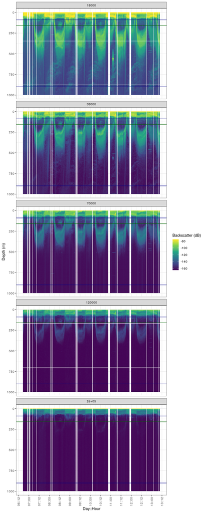

```r
dataBinned_01 %>% ggplot(aes(x = timeMex, y = depth_bin, fill = value)) + geom_tile() + scale_y_reverse() + scale_fill_viridis_c(limits = c(-165, -75), oob = scales::squish) +
  scale_x_datetime(breaks = timeBreaks, date_labels = "%d::%H") + labs(x = "Day::Hour", y = "Depth (m)", fill = "Backscatter (dB)") + theme_bw() + theme(axis.text.x = element_text(angle = 90, vjust = 0.5)) +
  geom_hline(yintercept = PhoticBase, color = "darkgreen") +
  geom_hline(yintercept = OMZBase, color = "darkblue") +
    geom_hline(yintercept = OMZTop, color = "darkblue") +


  facet_wrap(~frequency, ncol = 1)
```

```r
#ggsave("figures/stationP2_EK60_go7.svg", width = 4, height = 10)
ggsave("figures/stationP2_EK60_go7.png", width = 6, height = 10)
```